# 8

Рафи Кази ар

НКАбд-03-24

1032238132@pfur.ru

Кулябов Дмитрий Сергеевич

**Moscow**

**6.3. Последовательность выполнения работы**.

### Решение заданий лабораторной работы

**Примечание:** Все команды предполагается выполнять в терминале Linux. Замените username на ваше реальное имя пользователя.

**1. Осуществите вход в систему.**

- > Это действие выполняется на этапе загрузки ОС или при подключении к серверу по SSH.

**2. Запись названий файлов в file.txt**

# Записываем (перезаписываем) список файлов из /etc в file.txt  
ls /etc > file.txt  
# Дописываем (append) список файлов из домашнего каталога в тот же file.txt  
ls ~ >> file.txt

**3. Поиск .conf файлов и запись в conf.txt**

# Ищем в file.txt строки, содержащие ".conf", и записываем результат в conf.txt  
grep "\.conf$" file.txt > conf.txt

- > \. - экранирование точки (чтобы она означала именно точку, а не любой символ).
- > $ - означает "конец строки", так мы ищем именно расширение.

**4. Поиск файлов, начинающихся на 'c' в домашнем каталоге** **Вариант 1 (с помощью ls):**

ls ~/c*

**Вариант 2 (с помощью find - более надежный):**

find ~ -maxdepth 1 -name "c*" -type f

- > -maxdepth 1 - искать только в домашнем каталоге, не углубляясь в подкаталоги.

**Вариант 3 (с помощью конвейера и grep):**

ls ~ | grep "^c"

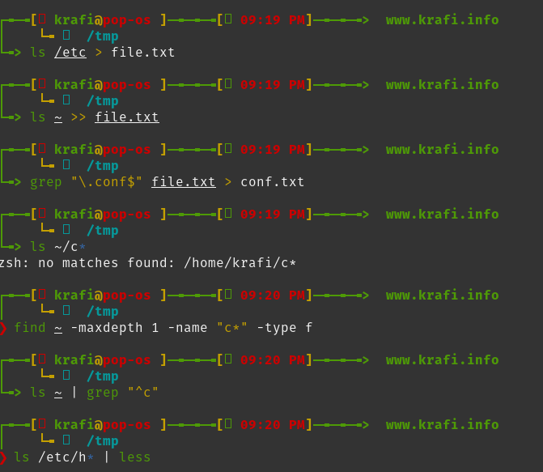

**5. Постраничный вывод файлов из /etc, начинающихся на 'h'**

ls /etc/h* | less

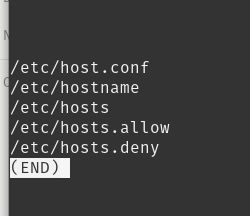

или

find /etc -maxdepth 1 -name "h*" -print | less

**6. Запуск фонового процесса поиска файлов log*

find / -name "log*" > ~/logfile 2> /dev/null &

- > 2> /dev/null - перенаправляет ошибки (например, "Permission denied") в "никуда", чтобы они не засоряли вывод.
- > & - запуск команды в фоновом режиме.

**7. Удаление файла ~/logfile**

rm ~/logfile

**8. Запуск gedit в фоновом режиме**

gedit &

- > После запуска вы увидите примерно: [1] 12345, где 1 - номер задачи (job), 12345 - PID процесса.

**9. Определение PID процесса gedit** **Способ 1 (через ps и grep):**

ps aux | grep gedit

[figure not shown]

- > В выводе вы увидите строку с процессом gedit и его PID (второй столбец).

**Способ 2 (через pgrep):**

pgrep gedit

- > Эта команда выведет только PID процесса.

**Способ 3 (через jobs -l):**

jobs -l

- > Команда покажет все задачи, запущенные из текущей оболочки, с их номерами и PID.

**10. Завершение процесса gedit с помощью kill**

- > Сначала смотрим справку: man kill
- > Основной синтаксис: kill [опции] <PID>
- > Завершаем процесс (подставив реальный PID, например, 12345):

kill 12345

- > Если процесс не реагирует, можно использовать kill -9 12345 (более жесткое, безусловное завершение).

**11. Выполнение команд df и du**

- > Читаем справку: man df, man du
- > Выполняем команды с полезными опциями:

df -h # Размеры разделов в удобном формате (G, M)  
du -sh ~/ # Суммарный размер домашнего каталога

[figure not shown]

**12. Поиск всех директорий в домашнем каталоге**

- > Читаем справку: man find

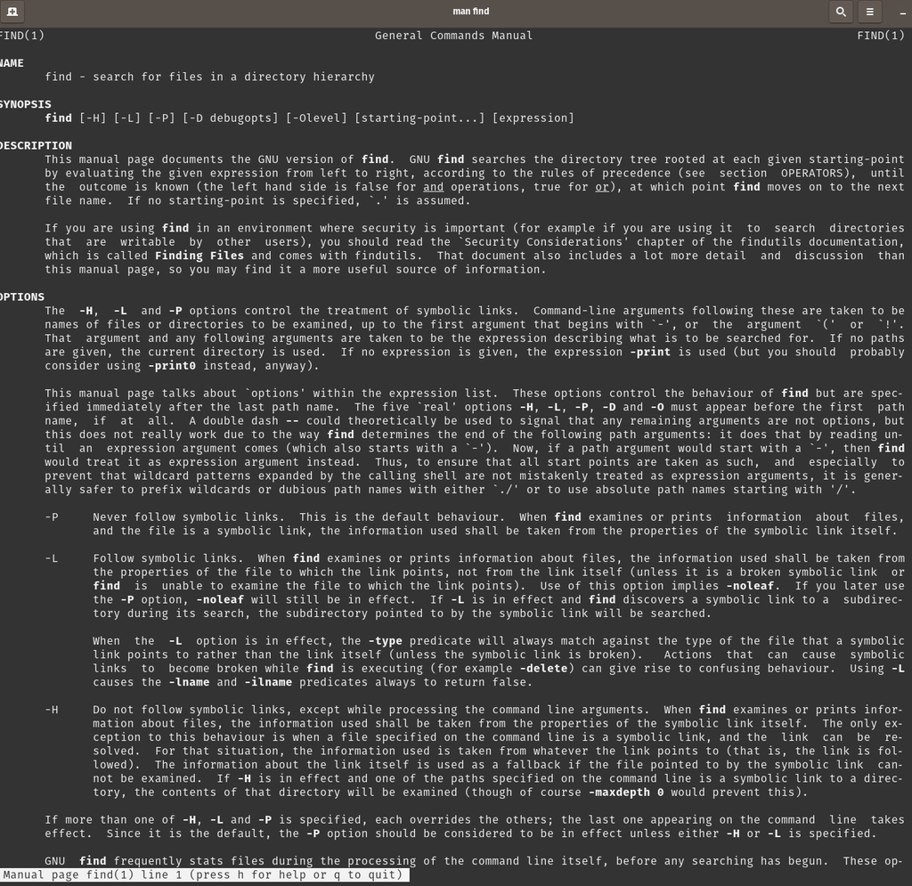

- > Выполняем поиск:

find ~ -type d

- > -type d - критерий поиска: найти только директории (d).

### Ответы на контрольные вопросы (6.5)

1. > **Какие потоки ввода вывода вы знаете?**
   - > stdin (0) - стандартный поток ввода (по умолчанию: клавиатура).
   - > stdout (1) - стандартный поток вывода (по умолчанию: экран).
   - > stderr (2) - стандартный поток ошибок (по умолчанию: экран).
2. > **Объясните разницу между операцией > и >>.**
   - > > - перенаправление вывода с **перезаписью** файла. Если файл существует, он будет стерт и создан заново.
   - > >> - перенаправление вывода с **добавлением** в конец файла. Если файл существует, данные будут дописаны после существующих.
3. > **Что такое конвейер?**
   - > Конвейер (|) - это механизм, который передает стандартный вывод (stdout) одной команды на стандартный ввод (stdin) другой команды. Позволяет объединять простые команды в мощные цепочки.
4. > **Что такое процесс? Чем это понятие отличается от программы?**
   - > **Программа** - это набор инструкций и данных, хранящийся на диске (исполняемый файл).
   - > **Процесс** - это экземпляр программы, **выполняющийся в памяти**. Он имеет свой собственный адресное пространство, ресурсы системы и идентификатор (PID). Одна программа может быть запущена в виде нескольких процессов.
5. > **Что такое PID и GID?**
   - > **PID (Process ID)** - уникальный числовой идентификатор процесса в системе.
   - > **GID (Group ID)** - идентификатор группы. Каждый пользователь и процесс принадлежит к одной или нескольким группам. **PPID (Parent Process ID)** - идентификатор процесса-родителя, который создал данный процесс.
6. > **Что такое задачи и какая команда позволяет ими управлять?**
   - > **Задачи (jobs)** - это процессы, запущенные в **фоновом режиме** из текущей оболочки (сессии терминала).
   - > Управлять ими позволяет команда jobs (показать список), а также:
     - > fg %N - вернуть задачу на передний план.
     - > bg %N - запустить остановленную задачу в фоне.
     - > kill %N - завершить задачу.
7. > **Найдите информацию об утилитах top и htop.**
   - > **top** - интерактивная консольная команда для мониторинга системы в реальном времени. Показывает список процессов, использование CPU, памяти, время работы и другую информацию.
   - > **htop** - улучшенная версия top. Имеет более удобный интерфейс с цветовым выделением, позволяет управлять процессами (завершать, менять приоритет) с помощью клавиш, имеет горизонтальную и вертикальную прокрутку.
8. > **Назовите и дайте характеристику команде поиска файлов.**
   - > **find** - мощнейшая команда для поиска файлов и каталогов по различным критериям: имя, размер, время изменения, тип файла, владелец и т.д. Может выполнять действия над найденными файлами (удалить, показать и др.).
   - > **Примеры:**
     - > find /home -name "*.txt" - найти все .txt файлы в /home.
     - > find . -size +10M - найти файлы больше 10 МБ в текущей директории.
     - > find /var/log -mtime -7 - найти файлы в /var/log, измененные за последние 7 дней.
9. > **Можно ли по контексту (содержанию) найти файл? Если да, то как?**
   - > **Да, можно.** Для этого используется команда grep в сочетании с рекурсивным обходом.
   - > **Команда:** grep -r "искомый_текст" /путь/для/поиска
   - > **Пример:** grep -r "Hello World" ~/projects/ - найдет все файлы в каталоге ~/projects/, внутри которых есть строка "Hello World".
10. > **Как определить объем свободной памяти на жёстком диске?**
    - > С помощью команды df (disk free).
    - > **Лучший вариант:** df -h - покажет размеры всех смонтированных разделов, занятое и свободное место в удобном для человека формате (ГиБ, МиБ).
11. > **Как определить объем вашего домашнего каталога?**
    - > С помощью команды du (disk usage).
    - > **Команда:** du -sh ~/
    - > -s - показать только итоговую сумму.
    - > -h - вывести размер в человеко-читаемом формате.
12. > **Как удалить зависший процесс?**
    1. > Найти PID зависшего процесса (например, firefox): pgrep firefox или ps aux | grep firefox.
    2. > Попытаться завершить его корректно: kill <PID>.
    3. > Если не помогает, принудительно завершить: kill -9 <PID> (сигнал SIGKILL, который нельзя перехватить или проигнорировать).